# Table of Contents

return home

# Motorcycle Kinetic Energy

## Introduction and approach

This notebook derives an equation for the kinetic energy of a motorcycle or bicycle according to the assumptions of the fourth order 'Whipple' style model. The model's composition and coordinate system are reproduced in Figure 1 below.

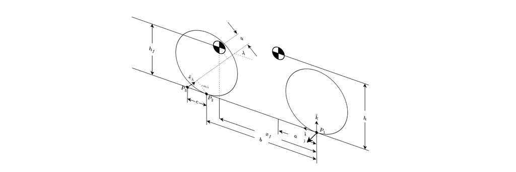

**Figure 1. Coordinate system for the fourth order motorcycle/bicycle model**

## Kinetic Energy of the rear frame

To find the kinetic energy of the rear frame of the bike, we first need to find the velocity of its center of mass, since kinetic energy can be written:

\begin{equation} T_r = \frac{1}{2}m_r\left| \vec{v}_r\right| ^2 \end{equation}

To find its velocity, we use the formula for [relative motion of points on a rigid body](http://emweb.unl.edu/NEGAHBAN/EM373/note15/note.htm):

\begin{equation} \vec{v}_b = \vec{v}_a + \vec{\omega}\times\vec{r}_{b/a} \end{equation}

In Eqn 2, $\vec{v}_b$ is the velocity of an unknown point of interest on the rigid body, $\vec{v}_a$ is the velocity of a point whose velocity is known, and $\vec{\omega}\times\vec{r}_{b/a}$ is the angular velocity of the body with respect to a Newtonian (non-moving) coordinate frame crossed with the position vector *from* point $a$ *to* point $b$. Note that the points $a$ and $b$ don't have to *physically* be on the body-- they just have to rotate and translate with the body's velocity.

For us, we do happen to know that if the bike's rear frame extended to the bike's coordinate origin, $P_1$, the ground-referenced velocity that point would simply be the bike's forward velocity, since the Whipple-style model assumes no lateral or longitudinal tire slip. Note that the velocity of the *rear wheel* at point $P_1$ would be *zero* for the same reason, but the rear wheel is *not* the same body as the bike's rear frame. Therefore, we can write:

\begin{equation} \vec{v}_{P1} = U\hat{\imath} \end{equation}

The angular velocity of the rear frame is unknown, but we can express it in terms of the derivatives of deegrees of freedom $\phi$ and $\psi$, since the rear frame is free to rotate in the $\hat{\imath}$ and $\hat{k}$ directions according to our model assumptions. Therefore, we can write:

\begin{equation} \vec{\omega}_{RF} = \dot{\phi}\hat{\imath}+\dot{\psi}\hat{k} \end{equation}

Finally, inspection of the figure above allows us to write the position of the rear frame's mass center with respect to $P_1$ as:

\begin{equation} \vec{r}_{RF/P1} = a\hat{\imath} + h_r\hat{k} \end{equation}

Then, we can compute the velocity of the rear frame's mass center as:

\begin{equation} \begin{aligned} \vec{v}_r &= \vec{v}_{P1} + \vec{\omega}_{RF} \times \vec{r}_{RF/P1}\\ &= U\hat{\imath} + \left(\dot{\phi}\hat{\imath} + \dot{\psi}\hat{k}\right)\times\left(a\hat{\imath}+h_r\hat{k}\right) \\ &= U\hat{\imath} + \left(a\dot{\psi} - h_r\dot{\phi}\right)\hat{\jmath} \end{aligned} \end{equation}

This means we can write the kinetic energy of the motorcycle's rear frame as:

\begin{equation} T_r = \frac{1}{2}m_r\left(U^2 + a^2\dot{\psi}^2 + h_r^2\dot{\phi}^2 - 2ah_r\dot{\psi}\dot{\phi}\right) \end{equation}

## Kinetic Energy of the Front Frame

We will use the same technique we used for the rear frame's kinetic energy for the front frame. The first task is to find the front frame mass center's velocity, which we will call $\vec{v}_{ff}$.

$P_3$ is the point where the steer axis intersects the ground plane, and because this point is coincident with the steer axis $\hat{e}_\lambda$, it is actually a point that could be considered a part of both the front and rear frames! To find the velocity of the front frame's mass center, we will first find the velocity of point $P_3$ using its location on the rear frame relative to point $P_1$, along with the rear frame's angular velocity.

\begin{equation} \begin{aligned} \vec{v}_{P3} &= \vec{v}_{P1} + \vec{\omega}_{RF}\times\vec{r}_{P3/P1} \\ &= U\hat{\imath} + \left(\dot{\phi}\hat{\imath}+\dot{\psi}\hat{k} \right)\times \left(b+c\right)\hat{\imath} \\ &= U\hat{\imath} + \left(b+c\right)\dot{\psi}\hat{j} \end{aligned} \end{equation}

Next, we note that since $P_3$ is also a point on the front frame, we could write:

\begin{equation} \vec{v}_{ff} = \vec{v}_{P3} + \vec{\omega}_{ff} \times \vec{r}_{ff/P3} \end{equation}

Where $\vec{\omega}_{ff} = \vec{\omega}_{rf} + \dot{\delta}\hat{e}_\lambda = \left(\left(\dot{\phi} -\dot{\delta}\cos\lambda\right)\hat{\imath} + \left(\dot{\psi} + \dot{\delta}\sin\lambda \right)\hat{k}\right)$, since the front frame has all of the angular velocity of the rear frame, **plus** angular velocity from steering motion.

\begin{equation} \vec{r}_{ff/P3} = \left(x_f-b-c\right)\hat{\imath}+h_f\hat{k} \end{equation}

Then, we can use the rigid body relative velocity equation again to find the velocity of the front frame's mass center.

\begin{equation} \begin{aligned} \vec{v}_{ff} &= \vec{v}_{P3} + \vec{\omega}_{ff} \times \vec{r}_{ff/P3}\\ &= U\hat{\imath} + \left(b+c\right)\dot{\psi}\hat{j} + \left(\left(\dot{\phi} -\dot{\delta}\cos\lambda\right)\hat{\imath} + \left(\dot{\psi} + \dot{\delta}\sin\lambda \right)\hat{k}\right) \times \left(x_f-b-c\right)\hat{\imath}+h_f\hat{k} \end{aligned} \end{equation}

Computing the cross product, canceling terms, and recognizing $u = h_f\cos\lambda - \left(b+c-x_f\right)\sin\lambda$ in the result yields a suitable final value for the front frame mass center's velocity:

\begin{equation} \vec{v}_{ff} = U\hat{\imath} + \left(\dot{\psi}x_f - \dot{\phi}h_f + \dot{\delta} u \right)\hat{\jmath} \end{equation}

Which allows us to compute the front frame's kinetic energy as $T_f = \frac{1}{2}m_f \left| \vec{v}_{ff}\right|^2$:

\begin{equation} T_f = \frac{1}{2} m_f \left(U^2 + \dot{\psi}^2x_f^2 + \dot{\phi}^2h_f^2 + \dot{\delta}^2u^2 - 2x_fh_f\dot{\psi}\dot{\phi} - 2uh_f\dot{\delta}\dot{\phi} +2x_fu\dot{\psi}\dot{\delta} \right) \end{equation}